# Advanced RNA-Seq and ChiP-Seq Data Analysis, 2017, European Bioinformatics Institute, Cambridge, UK

Federico Agostini, Nicolas Delhomme, Bori Mifsud, Gabriella Rustici, Bastian Schiffthaler, Charlotte Soneson

2017-04-24

# Sexual dimorphism study Biological QA

```r
    library(RnaSeqTutorial)
```

## (Re)Introduction

As a running example, we use a dataset derived from a study performed in Populus tremula (Robinson, Delhomme et al., BMC Plant Biology, 2014}. The authors test the evolutionary theory suggesting that males and females may evolve sexually dimorphic phenotypic and biochemical traits concordant with each sex having different optimal strategies of resource investment to maximise reproductive success and fitness. Such sexual dimorphism should result in sex biased gene expression patterns in non-floral organs for autosomal genes associated with the control and development of such phenotypic traits. Hence, the authors, among other approaches have looked for gene expression differences between sex. This was achieved by an RNA-Seq differential expression analysis between samples grouped by sex. The samples have been sequenced on an Illumina HiSeq 2000, using TruSeq adapters, through a 101 cycles paired-end protocol, which yielded between 11 million and 34 million reads per sample.

## Processing the data

### Reading in the data

First we read the HTSeq files in a matrix. The DESeq2 package now actually has a function to ease that process: DESeqDataSetFromHTSeqCount. Here we just process the samples in parallel using mclapply instead.

```r
res <- mclapply(dir(file.path(extdata(),"htseq"),
                    pattern="^[2,3].*_STAR\\.txt",
                    full.names=TRUE),function(fil){
  read.delim(fil,header=FALSE,stringsAsFactors=FALSE)
},mc.cores=2)
names(res) <- gsub("_.*_STAR\\.txt","",dir(file.path(extdata(),"htseq"),
                                           pattern="^[2,3].*_STAR\\.txt"))
```

Then we extract the additional info that HTSeq writes at the end of every file detailing how many reads are aligned uniquely or not, have no or ambigous overlaps or are of too low a quality. That last category should not occur at this stage of the analysis, as we have sorted and trimmed the data before aligning.

```r
addInfo <- c("__no_feature","__ambiguous",
             "__too_low_aQual","__not_aligned",
             "__alignment_not_unique")
```

and we then extract the reads

```r
sel <- match(addInfo,res[[1]][,1])
count.table <- do.call(cbind,lapply(res,"[",2))[-sel,]
colnames(count.table) <- names(res)
rownames(count.table) <- res[[1]][,1][-sel]
```

### The HTSeq stat lines

Here we aggreagte the information about how many reads aligned, how many were ambiguous, etc

```r
count.stats <- do.call(cbind,lapply(res,"[",2))[sel,]
colnames(count.stats) <- names(res)
rownames(count.stats) <- sub("__","",addInfo)
count.stats <- rbind(count.stats,aligned=colSums(count.table))
count.stats <- count.stats[rowSums(count.stats) > 0,]
```

Then we convert them as percentages and check them all

```r
apply(count.stats,2,function(co){round(co*100/sum(co))})
```

```
##                      202 207 213.1 221 226.1 229 229.1 235 236 239 244 303
## no_feature             7   8     7   7     7   8     7   7   7   7   8   7
## ambiguous              4   4     4   4     4   4     4   4   4   3   4   4
## alignment_not_unique   3   3     3   3     3   3     3   3   3   3   3   3
## aligned               86  85    86  87    86  86    86  86  86  86  86  86
##                      305.3 309.1 310.3 337.1 349.2
## no_feature               7     7     7     7     8
## ambiguous                4     4     4     4     4
## alignment_not_unique     3     3     3     3     3
## aligned                 87    86    86    86    85
```

As can be seen an average 86% of the reads aligned uniquely unambiguously to features. About 3% were mapping multiple locations, 4% were on ambigous features (as the data is non strand specific, we have used the “Union” counting scheme) and finally 7% align to no features. This is not at all unexpected given the fact that the alignments were done against the the draft of the P. tremula genome.

### Visualizing the HTSeq stats

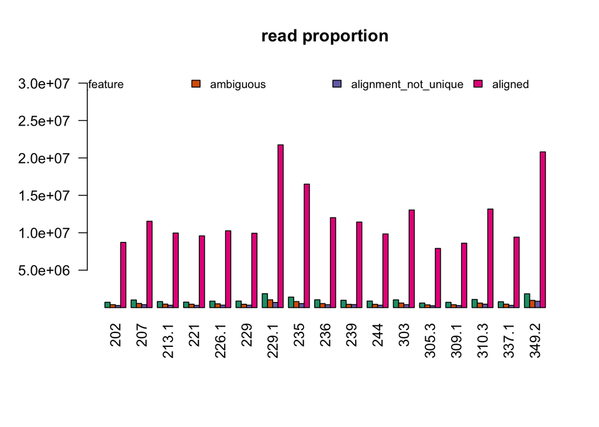

```r
pal=brewer.pal(6,"Dark2")[1:nrow(count.stats)]
mar <- par("mar")
par(mar=c(7.1,5.1,4.1,2.1))
barplot(as.matrix(count.stats),col=pal,beside=TRUE,las=2,main="read proportion",
        ylim=range(count.stats)+c(0,1e+7))
legend("top",fill=pal,legend=rownames(count.stats),bty="n",cex=0.8,horiz=TRUE)
```

```r
par(mar=mar)
```

Here, one can clearly see a library size effect; the samples 229.1 and 349.2 have been sequenced deeper as these are the parents of a large scale F1 population established for another study. Appart from these, the amount of reads per library seems fairly equally distributed.

### Deriving more information

We can estimate how much of the genes are not expressed

```r
sel <- rowSums(count.table) == 0
sprintf("%s percent",round(sum(sel) * 100/ nrow(count.table),digits=1))
```

```
## [1] "13.1 percent"
```

```r
sprintf("of %s genes are not expressed",nrow(count.table))
```

```
## [1] "of 35309 genes are not expressed"
```

So 13.1% of the genes are not expressed out of a total of 35309 genes

## Biological QA

To assess the validity of the replicates, we can look at different metrics.

### Raw count distribution

We start by looking at the per-gene mean expression, i.e. the mean raw count of every gene across samples is calculated and displayed on a log10 scale

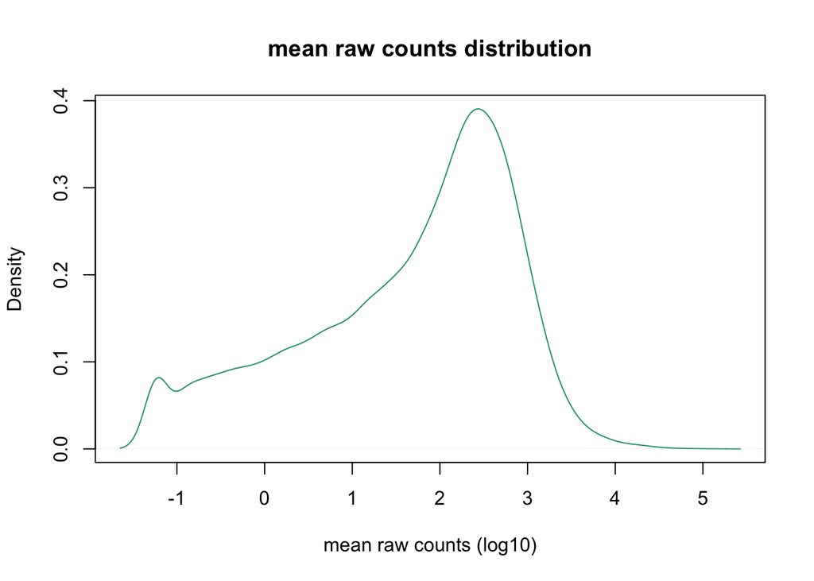

```r
plot(density(log10(rowMeans(count.table))),col=pal[1],
     main="mean raw counts distribution",
     xlab="mean raw counts (log10)")
```

Then the same is done for the individual samples colored by sample type

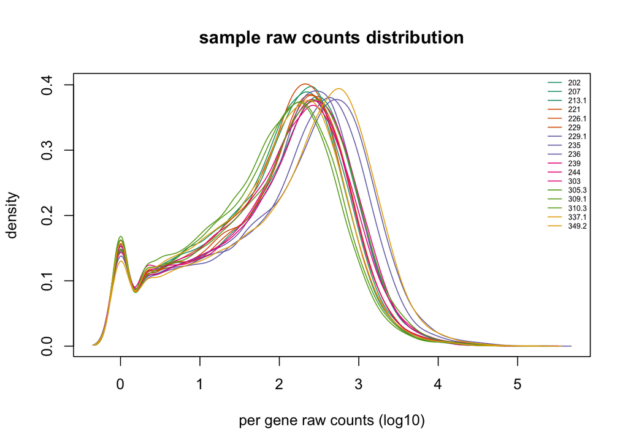

```r
pal=brewer.pal(8,"Dark2")
plot.multidensity(log10(count.table),col=rep(pal,each=3),
                  legend.x="topright",legend.cex=0.5,
                  main="sample raw counts distribution",
                  xlab="per gene raw counts (log10)")
```

As one can see, most samples show the similar trends, a few samples are shifted to the right - those that were sequenced deeper, but this does not affect the global shape of the curve.

## Variance stabilisation for better visualisation

For visualization, the data is submitted to a variance stabilization transformation using DESeq2. The dispersion is estimated independently of the sample type We nonetheless define the metadata fo importance, i.e. every sample sex and year of sampling

```r
samples <- read.csv(file.path(extdata(),"sex-samples.csv"))
conditions <- names(res)
sex <- samples$sex[match(names(res),samples$sample)]
date <- factor(samples$date[match(names(res),samples$sample)])
```

And then we create the DESeq2 object, using the sample name as condition (which is hence irrelevant to any comparison)

```r
dds <- DESeqDataSetFromMatrix(
  countData = count.table,
  colData = data.frame(condition=conditions,
                       sex=sex,
                       date=date),
  design = ~ condition)
```

Once this is done, we first check the size factors and as there is no big variation, we decide to go for a variance stabilisation transformation over a regularised log transformation. Check the DESeq2 vignette for more details about this.

```r
dds <- estimateSizeFactors(dds)
sizes <- sizeFactors(dds)
names(sizes) <- names(res)
sizes
```

```
##   202   207 213.1   221 226.1   229 229.1   235   236   239   244   303
##  0.79  1.06  0.88  0.81  0.91  0.93  1.89  1.51  1.09  1.06  0.90  0.99
## 305.3 309.1 310.3 337.1 349.2
##  0.65  0.71  1.10  0.80  1.94
```

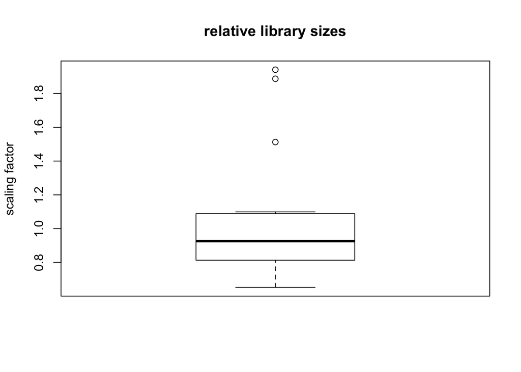

```r
boxplot(sizes,main="relative library sizes",ylab="scaling factor")
```

Let us do the vst

```r
colData(dds)$condition <- factor(colData(dds)$condition,
                                 levels=unique(conditions))
vsd <- varianceStabilizingTransformation(dds, blind=TRUE)
vst <- assay(vsd)
colnames(vst) <- colnames(count.table)
```

The vst introduces an offset, i.e. non expressed gene will have a value set as the minimal value of the vst. To avoid lengthy unnecessary explanations, we simply shift all values so that non expressed genes have a vst value of 0

```r
vst <- vst - min(vst)
```

It is then essential to validate the vst effect and ensure its validity. To that extend, we visualize the corrected mean - sd relationship. As it is fairly linear, meaning we can assume homoscedasticity. the slight initial trend / bump is due to genes having few counts in a few subset of the samples and hence having a higher variability. This is expected.

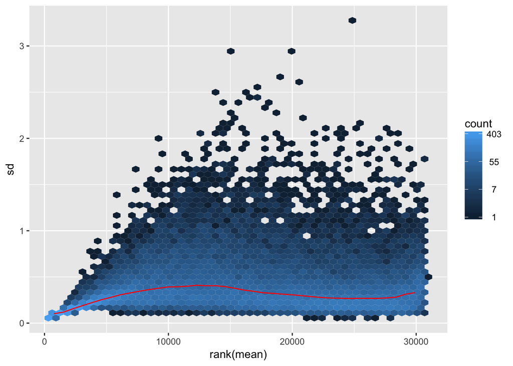

```r
meanSdPlot(assay(vsd)[rowSums(count.table)>0,])
```

Here is what would be observed by a log2 transformation of the raw count data

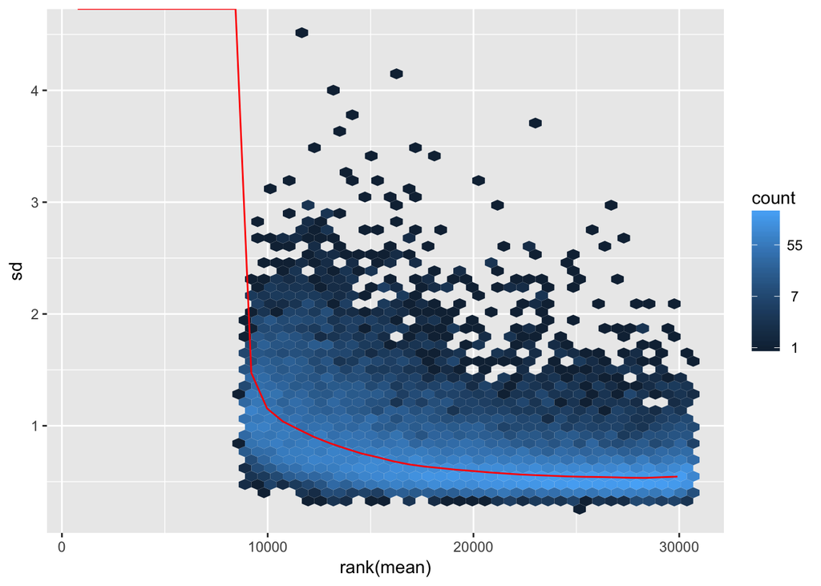

```r
meanSdPlot(log2(as.matrix(count.table[rowSums(count.table)>0,])))
```

or for the count adjusted for the library size factor

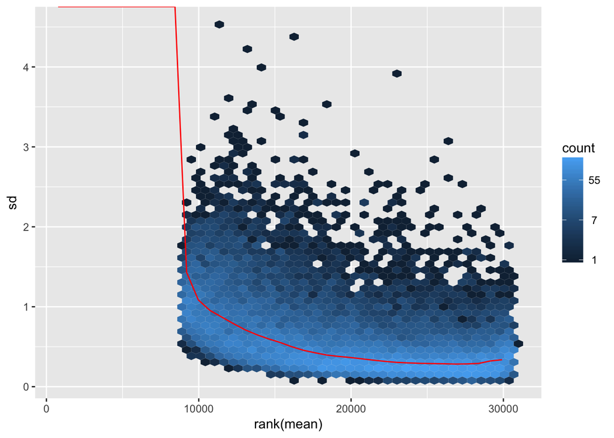

```r
meanSdPlot(log2(counts(dds,normalized=TRUE)[rowSums(count.table)>0,]))
```

### Time for Socrative question number 16

### PCA analysis

We perform a Principal Component Analysis (PCA) of the data to do a quick quality assessment, i.e. replicate should cluster and the first dimensions should be explainable by biological means.

```r
pc <- prcomp(t(vst))
percent <- round(summary(pc)$importance[2,]*100)
smpls <- conditions
```

We color the samples by date and sex

```r
sex.cols<-c("pink","lightblue")
sex.names<-c(F="Female",M="Male")
```

And then check wheter the observed separation is due to the sample sex

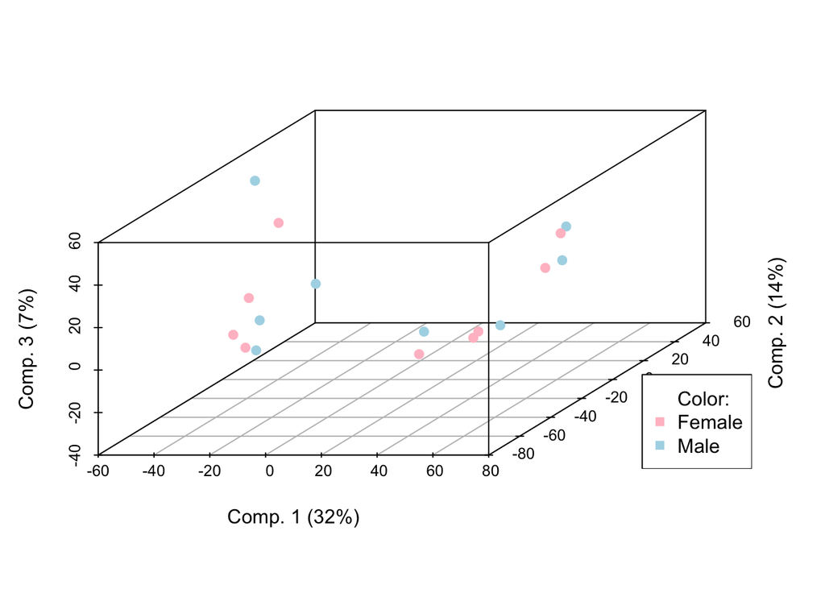

```r
scatterplot3d(pc$x[,1],
              pc$x[,2],
              pc$x[,3],
              xlab=paste("Comp. 1 (",percent[1],"%)",sep=""),
              ylab=paste("Comp. 2 (",percent[2],"%)",sep=""),
              zlab=paste("Comp. 3 (",percent[3],"%)",sep=""),
              color=sex.cols[as.integer(factor(sex))],
              pch=19)
legend("bottomright",pch=c(NA,15,15),col=c(NA,sex.cols[1:2]),
       legend=c("Color:",sex.names[levels(factor(sex))]))
```

```r
par(mar=mar)
```

This does not seem to be the case at all. There are 2 clusters of points, but both equally contain pink and blue dots. So, we next color by sampling date

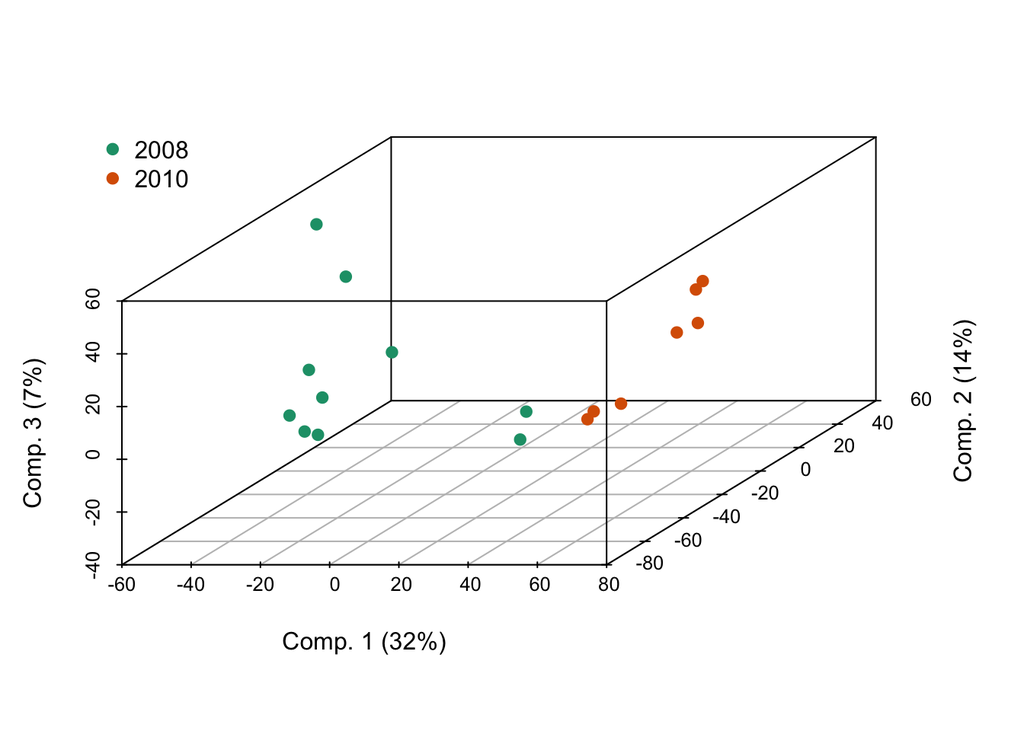

```r
dat <- date
scatterplot3d(pc$x[,1],
              pc$x[,2],
              pc$x[,3],
              xlab=paste("Comp. 1 (",percent[1],"%)",sep=""),
              ylab=paste("Comp. 2 (",percent[2],"%)",sep=""),
              zlab=paste("Comp. 3 (",percent[3],"%)",sep=""),
              color=pal[as.integer(factor(dat))],
              pch=19)
legend("topleft",pch=rep(c(19,23),each=10),col=rep(pal,2),legend=levels(factor(dat)),bty="n")
```

```r
par(mar=mar)
```

And here we are… The sampling data is a STRONG CONFOUNDING FACTOR in our analysis. So let’s do a final plot with the color = sex and shape = date

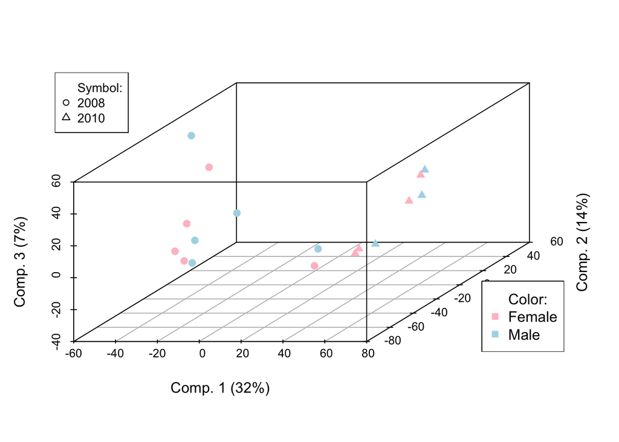

```r
scatterplot3d(pc$x[,1],
              pc$x[,2],
              pc$x[,3],
              xlab=paste("Comp. 1 (",percent[1],"%)",sep=""),
              ylab=paste("Comp. 2 (",percent[2],"%)",sep=""),
              zlab=paste("Comp. 3 (",percent[3],"%)",sep=""),
              color=sex.cols[as.integer(factor(sex))],
              pch=c(19,17)[as.integer(factor(dat))])
legend("bottomright",pch=c(NA,15,15),col=c(NA,sex.cols[1:2]),
       legend=c("Color:",sex.names[levels(factor(sex))]))
legend("topleft",pch=c(NA,21,24),col=c(NA,1,1),
       legend=c("Symbol:",levels(factor(dat))),cex=0.85)
```

```r
par(mar=mar)
```

Sometimes the 3D PCA are not so easy to read and we may be just as well off looking at 2 dimensions at a time. First the 2 first dims

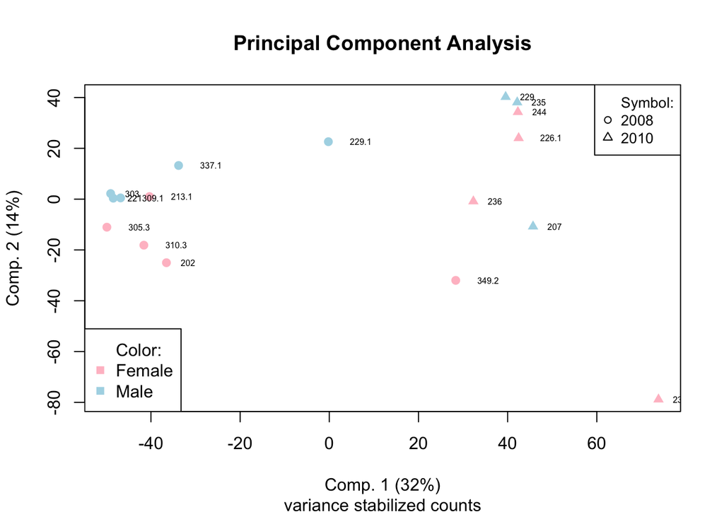

```r
plot(pc$x[,1],
     pc$x[,2],
     xlab=paste("Comp. 1 (",percent[1],"%)",sep=""),
     ylab=paste("Comp. 2 (",percent[2],"%)",sep=""),
     col=sex.cols[as.integer(factor(sex))],
     pch=c(19,17)[as.integer(factor(dat))],
     main="Principal Component Analysis",sub="variance stabilized counts")
legend("bottomleft",pch=c(NA,15,15),col=c(NA,sex.cols[1:2]),
       legend=c("Color:",sex.names[levels(factor(sex))]))
legend("topright",pch=c(NA,21,24),col=c(NA,1,1),
       legend=c("Symbol:",levels(factor(dat))),cex=0.85)
text(pc$x[,1],
     pc$x[,2],
     labels=conditions,cex=.5,adj=-1)
```

Clearly the sampling date separate most samples. It is interesting to see that the 2 samples sequenced deeper are in between the 2 clusters. We could hypothesize that the environmental change between sampling years are affecting less important genes, hence genes which expression levels are lower; i.e. somewhat looking at transcriptional “noise”. Since the 2 parent samples have been sequenced much deeper, the fact that they group with neither cluster might be due to that fact that they too have an increased proportion of transcriptional noise. Looking at the 2nd and 3rd dims does not reveal any obvious effects

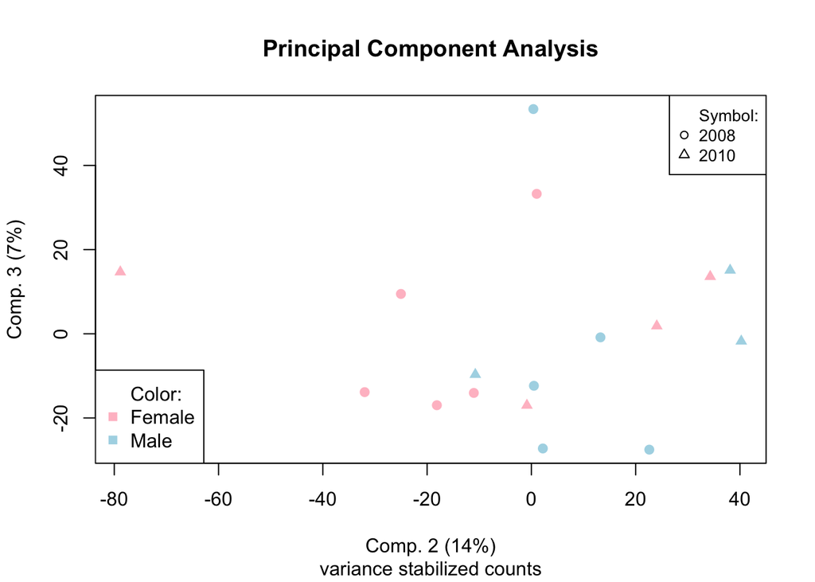

```r
plot(pc$x[,2],
     pc$x[,3],
     xlab=paste("Comp. 2 (",percent[2],"%)",sep=""),
     ylab=paste("Comp. 3 (",percent[3],"%)",sep=""),
     col=sex.cols[as.integer(factor(sex))],
     pch=c(19,17)[as.integer(factor(dat))],
     main="Principal Component Analysis",sub="variance stabilized counts")
legend("bottomleft",pch=c(NA,15,15),col=c(NA,sex.cols[1:2]),
       legend=c("Color:",sex.names[levels(factor(sex))]))
legend("topright",pch=c(NA,21,24),col=c(NA,1,1),
       legend=c("Symbol:",levels(factor(dat))),cex=0.85)
```

### Heatmap

Another way to look at the data is to create a heatmap. As heatmaps are computationally demanding and hard to read if there is too much data, we look only at the 1000 most variable genes

```r
sel <- order(apply(vst,1,sd),decreasing=TRUE)[1:1000]
```

First with their ID

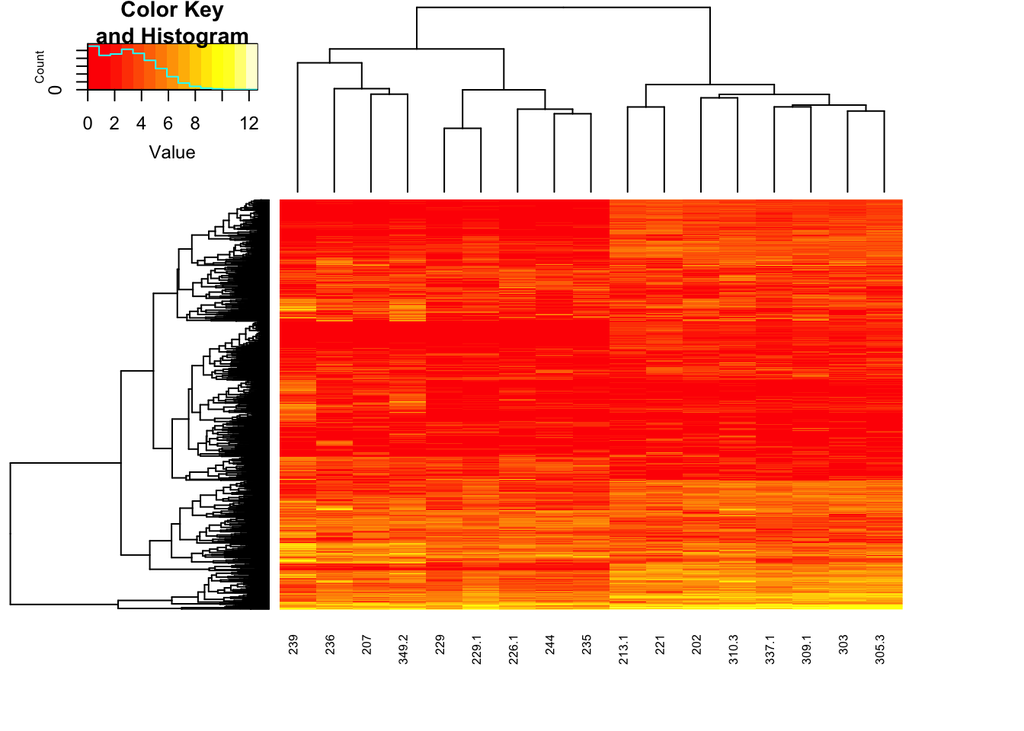

```r
heatmap.2(vst[sel,],labRow = NA,trace = "none",cexCol = 0.6 )
```

Then the sex

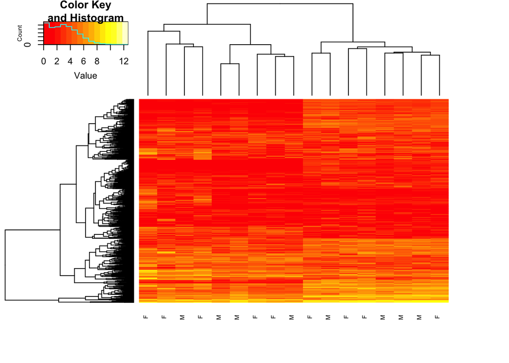

```r
heatmap.2(vst[sel,],labRow = NA, labCol = sex,trace = "none",cexCol = 0.6 )
```

And the date

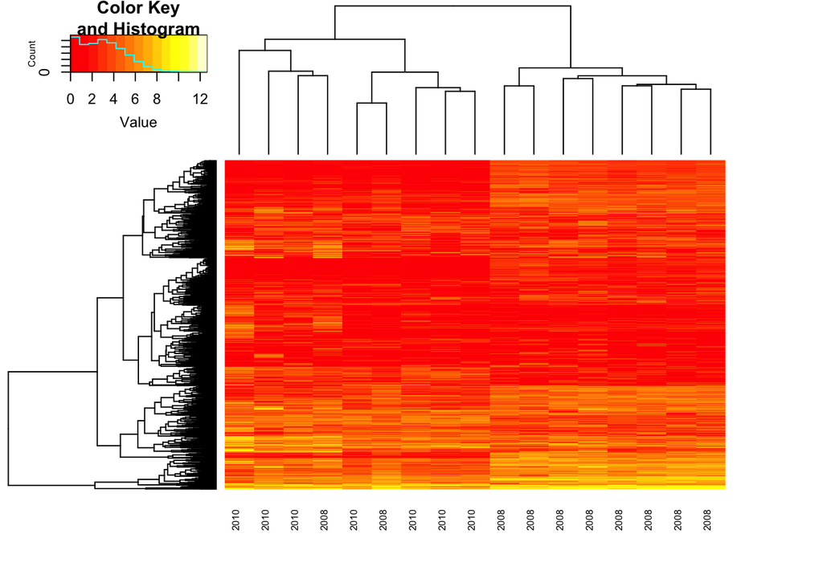

```r
heatmap.2(vst[sel,],labRow = NA, labCol = date,trace = "none",cexCol = 0.6 )
```

### Time for Socrative question number 17

# 1 References